```python
IFrame('https://www.kombo.co/en', width=800, height=600)
```

[interactive chart not shown]

# Table of Contents

# In a nutshell ...

make business recommendations

based on an analysis of transaction, web traffic and internet data

to a fast growing startup

Use exhaustive transaction data to get a detailed understanding of the business

Make recommendations on

- clients targets
- focused offering
- further data collection

All in "lean startup" spirit...

# Kombo

```python
IFrame('https://www.kombo.co/en/app/outward/1/89m8s-auucv/83bw6-b4iyk/2020-03-06/Paris/Chamonix/results', width=800, height=700)
```

[interactive chart not shown]

## business model

take advantage of transport liberalisation in Europe

- bus
- trains
- planes coming soon

genuinely multimodal / multi-carrier

i.e recommend starting with a bus/train company and finishing with another

- changing carrier can dramaticaly reduce price
- 60% of bus tickets involve 2 carriers

## differentiation

### genuine European multimodal booking is unique

[figure not shown]

### excellent technology

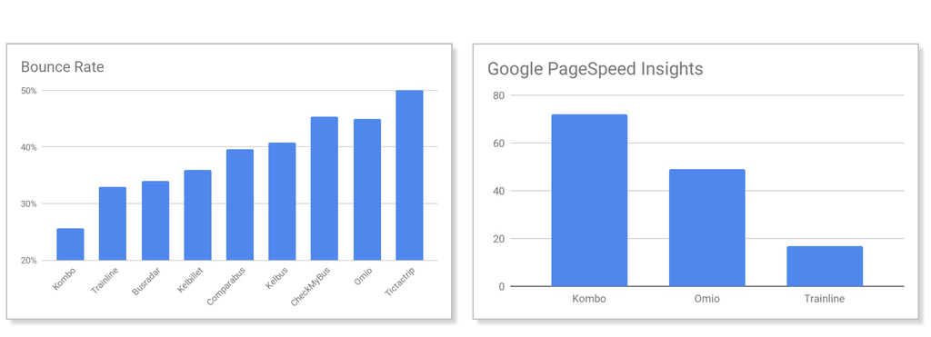

## proof of concept

- already largest reseller of Flixbus tickets in France
- contract signed with railway companies in Spain, Italy, Germany
- already high conversion rate
- good capacity to raise funds at high valuation

# Data

## quality data

exhaustive :

- bookings (checkout basket), including those not completed
- tickets and
- user data
- for the past 3 years : approx 200-250k records

clean

- acessible (SQL)
- well formatted (limited preprocessing)
- hardly any missing data

confidential - but no GDPR issues (emails anonymised)

```python
t_df = pd.read_csv('tickets_booked_data.csv')
t_df.rename(columns={'ìdx`' : 'booking_id',
                    '`booking_id`' : 'company_id',
                     ' `company_id`' : 'departure_id',
                     ' `departure_id`' : 'arrival_id',
                     ' `arrival_id`' : 'departure_time',
                      ' `departure_time`' : 'arrival_time',
                     ' `arrival_time`' : 'total_price',
                     ' `total_price`' : 'drop_me'

                    },
            inplace=True)
t_df = t_df[~t_df.booking_id.str.startswith('INS')]
t_df.drop('drop_me', axis=1, inplace=True)
t_df['booking_id'] = t_df['booking_id'].str.replace('(','').astype(int)
t_df['company_id'] = t_df['company_id'].astype(int)
t_df['departure_id'] = t_df['departure_id'].astype(int)
t_df['arrival_id'] = t_df['arrival_id'].astype(int)
t_df['departure_time'] = t_df['departure_time'].str.replace('T',' ')
t_df['departure_time'] = pd.to_datetime(t_df['departure_time'], format=" '%Y-%m-%d %H:%M:%S'")
t_df['arrival_time'] = t_df['arrival_time'].str.replace('T',' ')
t_df['arrival_time'] = pd.to_datetime(t_df['arrival_time'], format=" '%Y-%m-%d %H:%M:%S'")
t_df['total_price'] = t_df['total_price'].str.replace(';','')
t_df['total_price'] = t_df['total_price'].str.replace(')','')
t_df['total_price'] = t_df['total_price'].astype(int)
```

```python
t_df.head(5)
```

|  | booking_id | company_id | departure_id | arrival_id | departure_time | arrival_time | total_price |
| --- | --- | --- | --- | --- | --- | --- | --- |
| 0 | 5 | 3 | 582 | 39 | 2017-02-27 07:45:00 | 2017-02-27 09:40:00 | 1200 |
| 1 | 5 | 3 | 39 | 33 | 2017-02-27 11:00:00 | 2017-02-27 18:40:00 | 1900 |
| 2 | 6 | 3 | 1 | 29 | 2017-03-01 22:30:00 | 2017-03-02 06:30:00 | 1900 |
| 3 | 6 | 3 | 29 | 86 | 2017-03-02 08:00:00 | 2017-03-02 12:45:00 | 1400 |
| 4 | 7 | 3 | 1 | 29 | 2017-03-01 22:30:00 | 2017-03-02 06:30:00 | 1900 |

## basic exploration

```python
print(pd.unique(t_df['departure_id']).shape[0], pd.unique(t_df['arrival_id']).shape[0])
departure_id_freq = t_df['departure_id'].value_counts()
print(departure_id_freq[:5])
```

```
1568 1650
1     42146
18    15514
16     9853
11     8935
29     8398
Name: departure_id, dtype: int64
```

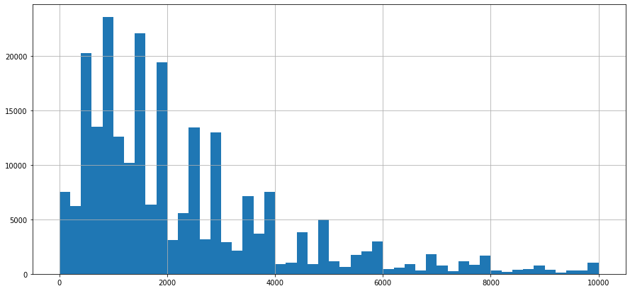

```python
plt.figure(figsize=(15, 7))
t_df[t_df['total_price'].between(left=0, right=10000)]['total_price'].hist(bins=50);
plt.show;
```

```python
print(f"bookings : {pd.unique(t_df['booking_id']).shape[0]}  - companies : {pd.unique(t_df['company_id']).shape[0]}")
```

```
bookings : 164509  - companies : 105
```

# Project

it's our project but company interested and supportive

quite a bit of flexibility - here are some toughts; you'll have more

## business analysis / intelligence based on transaction data

- who are the best clients
- where is the volume
- where is the margin
- conversion
- data potentially available on a daily basis; where relevant analysis can be made in quasi realtime

## web analytics & social media

Google analytics

Facebook traffic

## 3rd party data

web scrapping ... https://fr.trustpilot.com/review/kombo.co

## techniques

modelling

- many sklearn models
- deep learning

offline analysis looks manageable on mac / colab

some replicable analysis may warrant deployment to could infrastructure (GCP or company provided...)